# Risk Factor Analysis

## Outcome Variable

**Outcome Variable:** haz

## Predictor Variables

**Intervention Variable:** vagbrth

**Adjustment Set:**

- arm
- sex
- W_mage
- meducyrs
- feducyrs
- hhwealth_quart
- W_mhtcm
- W_mwtkg
- W_mbmi
- single
- W_nrooms
- brthmon
- W_parity
- impfloor
- delta_W_mage
- delta_meducyrs
- delta_feducyrs
- delta_hhwealth_quart
- delta_W_mhtcm
- delta_W_mwtkg
- delta_W_mbmi
- delta_single
- delta_W_nrooms
- delta_brthmon
- delta_W_parity
- delta_impfloor

## Stratifying Variables

The analysis was stratified on these variable(s):

- agecat
- studyid
- country

## Data Summary

| agecat | studyid | country | vagbrth | n_cell | n |
| --- | --- | --- | --- | --- | --- |
| Birth | ki1000108-CMC-V-BCS-2002 | INDIA | 0 | 11 | 92 |
| Birth | ki1000108-CMC-V-BCS-2002 | INDIA | 1 | 81 | 92 |
| Birth | ki1000108-IRC | INDIA | 0 | 68 | 388 |
| Birth | ki1000108-IRC | INDIA | 1 | 320 | 388 |
| Birth | ki1017093b-PROVIDE | BANGLADESH | 0 | 108 | 539 |
| Birth | ki1017093b-PROVIDE | BANGLADESH | 1 | 431 | 539 |
| Birth | ki1017093c-NIH-Crypto | BANGLADESH | 0 | 186 | 477 |
| Birth | ki1017093c-NIH-Crypto | BANGLADESH | 1 | 291 | 477 |
| Birth | ki1119695-PROBIT | BELARUS | 0 | 1597 | 13890 |
| Birth | ki1119695-PROBIT | BELARUS | 1 | 12293 | 13890 |
| Birth | ki1126311-ZVITAMBO | ZIMBABWE | 0 | 1166 | 13761 |
| Birth | ki1126311-ZVITAMBO | ZIMBABWE | 1 | 12595 | 13761 |
| Birth | kiGH5241-JiVitA-3 | BANGLADESH | 0 | 539 | 22418 |
| Birth | kiGH5241-JiVitA-3 | BANGLADESH | 1 | 21879 | 22418 |
| Birth | kiGH5241-JiVitA-4 | BANGLADESH | 0 | 76 | 2822 |
| Birth | kiGH5241-JiVitA-4 | BANGLADESH | 1 | 2746 | 2822 |
| 6 months | ki1000108-CMC-V-BCS-2002 | INDIA | 0 | 25 | 369 |
| 6 months | ki1000108-CMC-V-BCS-2002 | INDIA | 1 | 344 | 369 |
| 6 months | ki1000108-IRC | INDIA | 0 | 69 | 407 |
| 6 months | ki1000108-IRC | INDIA | 1 | 338 | 407 |
| 6 months | ki1017093b-PROVIDE | BANGLADESH | 0 | 139 | 604 |
| 6 months | ki1017093b-PROVIDE | BANGLADESH | 1 | 465 | 604 |
| 6 months | ki1017093c-NIH-Crypto | BANGLADESH | 0 | 187 | 457 |
| 6 months | ki1017093c-NIH-Crypto | BANGLADESH | 1 | 270 | 457 |
| 6 months | ki1066203-TanzaniaChild2 | TANZANIA, UNITED REPUBLIC OF | 0 | 189 | 2005 |
| 6 months | ki1066203-TanzaniaChild2 | TANZANIA, UNITED REPUBLIC OF | 1 | 1816 | 2005 |
| 6 months | ki1119695-PROBIT | BELARUS | 0 | 1799 | 15761 |
| 6 months | ki1119695-PROBIT | BELARUS | 1 | 13962 | 15761 |
| 6 months | ki1126311-ZVITAMBO | ZIMBABWE | 0 | 740 | 8601 |
| 6 months | ki1126311-ZVITAMBO | ZIMBABWE | 1 | 7861 | 8601 |
| 6 months | kiGH5241-JiVitA-3 | BANGLADESH | 0 | 1077 | 16732 |
| 6 months | kiGH5241-JiVitA-3 | BANGLADESH | 1 | 15655 | 16732 |
| 6 months | kiGH5241-JiVitA-4 | BANGLADESH | 0 | 336 | 4052 |
| 6 months | kiGH5241-JiVitA-4 | BANGLADESH | 1 | 3716 | 4052 |
| 24 months | ki1000108-CMC-V-BCS-2002 | INDIA | 0 | 24 | 371 |
| 24 months | ki1000108-CMC-V-BCS-2002 | INDIA | 1 | 347 | 371 |
| 24 months | ki1000108-IRC | INDIA | 0 | 69 | 409 |
| 24 months | ki1000108-IRC | INDIA | 1 | 340 | 409 |
| 24 months | ki1017093b-PROVIDE | BANGLADESH | 0 | 137 | 578 |
| 24 months | ki1017093b-PROVIDE | BANGLADESH | 1 | 441 | 578 |
| 24 months | ki1017093c-NIH-Crypto | BANGLADESH | 0 | 99 | 260 |
| 24 months | ki1017093c-NIH-Crypto | BANGLADESH | 1 | 161 | 260 |
| 24 months | ki1066203-TanzaniaChild2 | TANZANIA, UNITED REPUBLIC OF | 0 | 2 | 6 |
| 24 months | ki1066203-TanzaniaChild2 | TANZANIA, UNITED REPUBLIC OF | 1 | 4 | 6 |
| 24 months | ki1119695-PROBIT | BELARUS | 0 | 472 | 4035 |
| 24 months | ki1119695-PROBIT | BELARUS | 1 | 3563 | 4035 |
| 24 months | ki1126311-ZVITAMBO | ZIMBABWE | 0 | 133 | 1619 |
| 24 months | ki1126311-ZVITAMBO | ZIMBABWE | 1 | 1486 | 1619 |
| 24 months | kiGH5241-JiVitA-3 | BANGLADESH | 0 | 480 | 8584 |
| 24 months | kiGH5241-JiVitA-3 | BANGLADESH | 1 | 8104 | 8584 |
| 24 months | kiGH5241-JiVitA-4 | BANGLADESH | 0 | 323 | 4020 |
| 24 months | kiGH5241-JiVitA-4 | BANGLADESH | 1 | 3697 | 4020 |

The following strata were considered:

- agecat: 24 months, studyid: ki1000108-CMC-V-BCS-2002, country: INDIA
- agecat: 24 months, studyid: ki1000108-IRC, country: INDIA
- agecat: 24 months, studyid: ki1017093b-PROVIDE, country: BANGLADESH
- agecat: 24 months, studyid: ki1017093c-NIH-Crypto, country: BANGLADESH
- agecat: 24 months, studyid: ki1066203-TanzaniaChild2, country: TANZANIA, UNITED REPUBLIC OF
- agecat: 24 months, studyid: ki1119695-PROBIT, country: BELARUS
- agecat: 24 months, studyid: ki1126311-ZVITAMBO, country: ZIMBABWE
- agecat: 24 months, studyid: kiGH5241-JiVitA-3, country: BANGLADESH
- agecat: 24 months, studyid: kiGH5241-JiVitA-4, country: BANGLADESH
- agecat: 6 months, studyid: ki1000108-CMC-V-BCS-2002, country: INDIA
- agecat: 6 months, studyid: ki1000108-IRC, country: INDIA
- agecat: 6 months, studyid: ki1017093b-PROVIDE, country: BANGLADESH
- agecat: 6 months, studyid: ki1017093c-NIH-Crypto, country: BANGLADESH
- agecat: 6 months, studyid: ki1066203-TanzaniaChild2, country: TANZANIA, UNITED REPUBLIC OF
- agecat: 6 months, studyid: ki1119695-PROBIT, country: BELARUS
- agecat: 6 months, studyid: ki1126311-ZVITAMBO, country: ZIMBABWE
- agecat: 6 months, studyid: kiGH5241-JiVitA-3, country: BANGLADESH
- agecat: 6 months, studyid: kiGH5241-JiVitA-4, country: BANGLADESH
- agecat: Birth, studyid: ki1000108-CMC-V-BCS-2002, country: INDIA
- agecat: Birth, studyid: ki1000108-IRC, country: INDIA
- agecat: Birth, studyid: ki1017093b-PROVIDE, country: BANGLADESH
- agecat: Birth, studyid: ki1017093c-NIH-Crypto, country: BANGLADESH
- agecat: Birth, studyid: ki1119695-PROBIT, country: BELARUS
- agecat: Birth, studyid: ki1126311-ZVITAMBO, country: ZIMBABWE
- agecat: Birth, studyid: kiGH5241-JiVitA-3, country: BANGLADESH
- agecat: Birth, studyid: kiGH5241-JiVitA-4, country: BANGLADESH

### Dropped Strata

Some strata were dropped due to rare outcomes:

- agecat: 24 months, studyid: ki1066203-TanzaniaChild2, country: TANZANIA, UNITED REPUBLIC OF

## Methods Detail

We’re interested in the causal parameters $E[Y_a]$ for all values of $a \in \mathcal{A}$. These parameters represent the mean outcome if, possibly contrary to fact, we intervened to set all units to have $A=a$. Under the randomization and positivity assumptions, these are identified by the statistical parameters $\psi_a=E_W[E_{Y|A,W}(Y|A=a,W)]$. In addition, we’re interested in the mean of $Y$, $E[Y]$ under no intervention (the observed mean). We will estimate these parameters by using SuperLearner to fit the relevant likelihood factors – $E_{Y|A,W}(Y|A=a,W)$ and $p(A=a|W)$, and then updating our likelihood fit using a joint TMLE.

For unadjusted analyses ($W=\{\}$), initial likelihoods were estimated using Lrnr_glm to estimate the simple $E(Y|A)$ and Lrnr_mean to estimate $p(A)$. For adjusted analyses, a small library containing Lrnr_glmnet, Lrnr_xgboost, and Lrnr_mean was used.

Having estimated these parameters, we will then use the delta method to estimate relative risks and attributable risks relative to a prespecified baseline level of $A$.

# Results Detail

## Results Plots

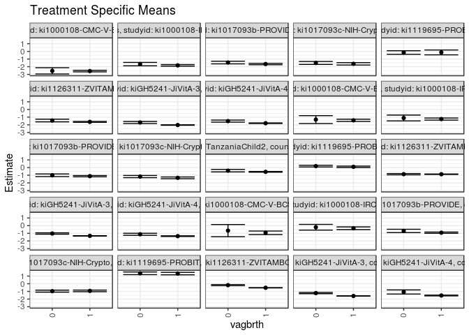

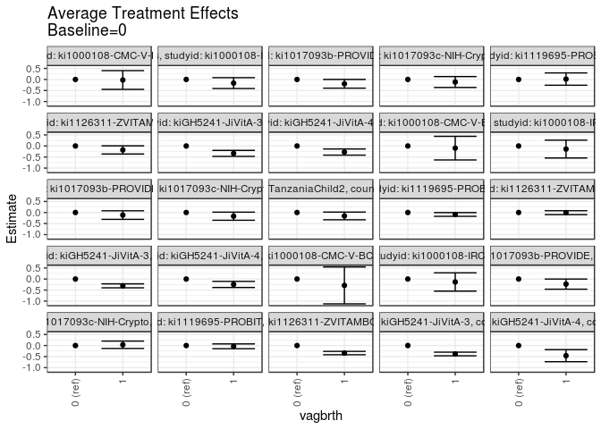

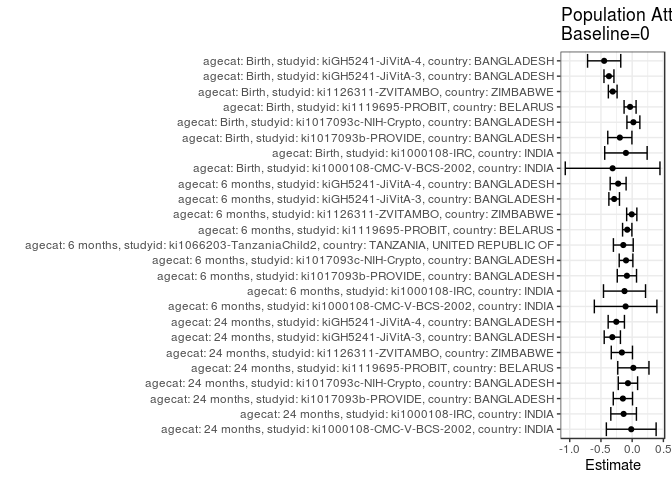

## Results Table

### Parameter: TSM

| agecat | studyid | country | intervention_level | baseline_level | estimate | ci_lower | ci_upper |
| --- | --- | --- | --- | --- | --- | --- | --- |
| Birth | ki1000108-CMC-V-BCS-2002 | INDIA | 0 | NA | -0.6480455 | -1.4427618 | 0.1466708 |
| Birth | ki1000108-CMC-V-BCS-2002 | INDIA | 1 | NA | -0.9362396 | -1.1684195 | -0.7040597 |
| Birth | ki1000108-IRC | INDIA | 0 | NA | -0.2080771 | -0.5824170 | 0.1662628 |
| Birth | ki1000108-IRC | INDIA | 1 | NA | -0.3415642 | -0.5180489 | -0.1650795 |
| Birth | ki1017093b-PROVIDE | BANGLADESH | 0 | NA | -0.6878466 | -0.9036688 | -0.4720245 |
| Birth | ki1017093b-PROVIDE | BANGLADESH | 1 | NA | -0.9182757 | -0.9991409 | -0.8374104 |
| Birth | ki1017093c-NIH-Crypto | BANGLADESH | 0 | NA | -0.9675872 | -1.0978570 | -0.8373174 |
| Birth | ki1017093c-NIH-Crypto | BANGLADESH | 1 | NA | -0.9331751 | -1.0390015 | -0.8273486 |
| Birth | ki1119695-PROBIT | BELARUS | 0 | NA | 1.3603641 | 1.1863580 | 1.5343702 |
| Birth | ki1119695-PROBIT | BELARUS | 1 | NA | 1.3256397 | 1.1645646 | 1.4867149 |
| Birth | ki1126311-ZVITAMBO | ZIMBABWE | 0 | NA | -0.1856064 | -0.2583983 | -0.1128146 |
| Birth | ki1126311-ZVITAMBO | ZIMBABWE | 1 | NA | -0.5255505 | -0.5470667 | -0.5040343 |
| Birth | kiGH5241-JiVitA-3 | BANGLADESH | 0 | NA | -1.2174352 | -1.2987753 | -1.1360951 |
| Birth | kiGH5241-JiVitA-3 | BANGLADESH | 1 | NA | -1.5986134 | -1.6181314 | -1.5790953 |
| Birth | kiGH5241-JiVitA-4 | BANGLADESH | 0 | NA | -1.0745235 | -1.3428831 | -0.8061640 |
| Birth | kiGH5241-JiVitA-4 | BANGLADESH | 1 | NA | -1.5330147 | -1.5830554 | -1.4829740 |
| 6 months | ki1000108-CMC-V-BCS-2002 | INDIA | 0 | NA | -1.3184882 | -1.8307247 | -0.8062516 |
| 6 months | ki1000108-CMC-V-BCS-2002 | INDIA | 1 | NA | -1.4167526 | -1.5638861 | -1.2696191 |
| 6 months | ki1000108-IRC | INDIA | 0 | NA | -1.1118394 | -1.4928955 | -0.7307833 |
| 6 months | ki1000108-IRC | INDIA | 1 | NA | -1.2524109 | -1.3900781 | -1.1147437 |
| 6 months | ki1017093b-PROVIDE | BANGLADESH | 0 | NA | -1.0071983 | -1.1815863 | -0.8328102 |
| 6 months | ki1017093b-PROVIDE | BANGLADESH | 1 | NA | -1.1234010 | -1.2080406 | -1.0387614 |
| 6 months | ki1017093c-NIH-Crypto | BANGLADESH | 0 | NA | -1.1750669 | -1.3171251 | -1.0330087 |
| 6 months | ki1017093c-NIH-Crypto | BANGLADESH | 1 | NA | -1.3421471 | -1.4580238 | -1.2262704 |
| 6 months | ki1066203-TanzaniaChild2 | TANZANIA, UNITED REPUBLIC OF | 0 | NA | -0.4037529 | -0.5700325 | -0.2374733 |
| 6 months | ki1066203-TanzaniaChild2 | TANZANIA, UNITED REPUBLIC OF | 1 | NA | -0.5587001 | -0.6103593 | -0.5070410 |
| 6 months | ki1119695-PROBIT | BELARUS | 0 | NA | 0.1859450 | 0.0764173 | 0.2954726 |
| 6 months | ki1119695-PROBIT | BELARUS | 1 | NA | 0.0971138 | 0.0005913 | 0.1936363 |
| 6 months | ki1126311-ZVITAMBO | ZIMBABWE | 0 | NA | -0.8619039 | -0.9468185 | -0.7769892 |
| 6 months | ki1126311-ZVITAMBO | ZIMBABWE | 1 | NA | -0.8692870 | -0.8962529 | -0.8423212 |
| 6 months | kiGH5241-JiVitA-3 | BANGLADESH | 0 | NA | -1.0252351 | -1.1129026 | -0.9375677 |
| 6 months | kiGH5241-JiVitA-3 | BANGLADESH | 1 | NA | -1.3331317 | -1.3562057 | -1.3100576 |
| 6 months | kiGH5241-JiVitA-4 | BANGLADESH | 0 | NA | -1.1253241 | -1.2579885 | -0.9926596 |
| 6 months | kiGH5241-JiVitA-4 | BANGLADESH | 1 | NA | -1.3698398 | -1.4136441 | -1.3260355 |
| 24 months | ki1000108-CMC-V-BCS-2002 | INDIA | 0 | NA | -2.5439793 | -2.9554387 | -2.1325199 |
| 24 months | ki1000108-CMC-V-BCS-2002 | INDIA | 1 | NA | -2.5687759 | -2.6716480 | -2.4659039 |
| 24 months | ki1000108-IRC | INDIA | 0 | NA | -1.6618337 | -1.8838221 | -1.4398453 |
| 24 months | ki1000108-IRC | INDIA | 1 | NA | -1.8267529 | -1.9300457 | -1.7234600 |
| 24 months | ki1017093b-PROVIDE | BANGLADESH | 0 | NA | -1.4540040 | -1.6265203 | -1.2814876 |
| 24 months | ki1017093b-PROVIDE | BANGLADESH | 1 | NA | -1.6500319 | -1.7451261 | -1.5549377 |
| 24 months | ki1017093c-NIH-Crypto | BANGLADESH | 0 | NA | -1.5098196 | -1.7019135 | -1.3177257 |
| 24 months | ki1017093c-NIH-Crypto | BANGLADESH | 1 | NA | -1.6256135 | -1.7818229 | -1.4694040 |
| 24 months | ki1119695-PROBIT | BELARUS | 0 | NA | -0.1504763 | -0.3844403 | 0.0834878 |
| 24 months | ki1119695-PROBIT | BELARUS | 1 | NA | -0.1336109 | -0.4493538 | 0.1821321 |
| 24 months | ki1126311-ZVITAMBO | ZIMBABWE | 0 | NA | -1.4395856 | -1.6154694 | -1.2637019 |
| 24 months | ki1126311-ZVITAMBO | ZIMBABWE | 1 | NA | -1.6191746 | -1.6793245 | -1.5590246 |
| 24 months | kiGH5241-JiVitA-3 | BANGLADESH | 0 | NA | -1.6965669 | -1.8314887 | -1.5616451 |
| 24 months | kiGH5241-JiVitA-3 | BANGLADESH | 1 | NA | -2.0316596 | -2.0591852 | -2.0041340 |
| 24 months | kiGH5241-JiVitA-4 | BANGLADESH | 0 | NA | -1.5193380 | -1.6562891 | -1.3823868 |
| 24 months | kiGH5241-JiVitA-4 | BANGLADESH | 1 | NA | -1.7943607 | -1.8337185 | -1.7550028 |

### Parameter: E(Y)

| agecat | studyid | country | intervention_level | baseline_level | estimate | ci_lower | ci_upper |
| --- | --- | --- | --- | --- | --- | --- | --- |
| Birth | ki1000108-CMC-V-BCS-2002 | INDIA | NA | NA | -0.9611957 | -1.1776967 | -0.7446946 |
| Birth | ki1000108-IRC | INDIA | NA | NA | -0.3080412 | -0.4687931 | -0.1472894 |
| Birth | ki1017093b-PROVIDE | BANGLADESH | NA | NA | -0.8851020 | -0.9601332 | -0.8100709 |
| Birth | ki1017093c-NIH-Crypto | BANGLADESH | NA | NA | -0.9480084 | -1.0301396 | -0.8658772 |
| Birth | ki1119695-PROBIT | BELARUS | NA | NA | 1.3269446 | 1.1683850 | 1.4855041 |
| Birth | ki1126311-ZVITAMBO | ZIMBABWE | NA | NA | -0.4970772 | -0.5177022 | -0.4764523 |
| Birth | kiGH5241-JiVitA-3 | BANGLADESH | NA | NA | -1.5892417 | -1.6084834 | -1.5700000 |
| Birth | kiGH5241-JiVitA-4 | BANGLADESH | NA | NA | -1.5231680 | -1.5722488 | -1.4740872 |
| 6 months | ki1000108-CMC-V-BCS-2002 | INDIA | NA | NA | -1.4234508 | -1.5645974 | -1.2823042 |
| 6 months | ki1000108-IRC | INDIA | NA | NA | -1.2344062 | -1.3658524 | -1.1029600 |
| 6 months | ki1017093b-PROVIDE | BANGLADESH | NA | NA | -1.0916915 | -1.1661176 | -1.0172654 |
| 6 months | ki1017093c-NIH-Crypto | BANGLADESH | NA | NA | -1.2731619 | -1.3626957 | -1.1836282 |
| 6 months | ki1066203-TanzaniaChild2 | TANZANIA, UNITED REPUBLIC OF | NA | NA | -0.5455565 | -0.5948696 | -0.4962435 |
| 6 months | ki1119695-PROBIT | BELARUS | NA | NA | 0.1069986 | 0.0122286 | 0.2017686 |
| 6 months | ki1126311-ZVITAMBO | ZIMBABWE | NA | NA | -0.8685914 | -0.8942954 | -0.8428875 |
| 6 months | kiGH5241-JiVitA-3 | BANGLADESH | NA | NA | -1.3134013 | -1.3366073 | -1.2901952 |
| 6 months | kiGH5241-JiVitA-4 | BANGLADESH | NA | NA | -1.3500888 | -1.3921730 | -1.3080047 |
| 24 months | ki1000108-CMC-V-BCS-2002 | INDIA | NA | NA | -2.5588679 | -2.6583730 | -2.4593629 |
| 24 months | ki1000108-IRC | INDIA | NA | NA | -1.7987775 | -1.8923914 | -1.7051636 |
| 24 months | ki1017093b-PROVIDE | BANGLADESH | NA | NA | -1.6024221 | -1.6857420 | -1.5191023 |
| 24 months | ki1017093c-NIH-Crypto | BANGLADESH | NA | NA | -1.5776538 | -1.6988448 | -1.4564629 |
| 24 months | ki1119695-PROBIT | BELARUS | NA | NA | -0.1314048 | -0.4282725 | 0.1654630 |
| 24 months | ki1126311-ZVITAMBO | ZIMBABWE | NA | NA | -1.6043391 | -1.6616652 | -1.5470130 |
| 24 months | kiGH5241-JiVitA-3 | BANGLADESH | NA | NA | -2.0144245 | -2.0420946 | -1.9867544 |
| 24 months | kiGH5241-JiVitA-4 | BANGLADESH | NA | NA | -1.7734527 | -1.8119258 | -1.7349797 |

### Parameter: ATE

| agecat | studyid | country | intervention_level | baseline_level | estimate | ci_lower | ci_upper |
| --- | --- | --- | --- | --- | --- | --- | --- |
| Birth | ki1000108-CMC-V-BCS-2002 | INDIA | 0 | 0 | 0.0000000 | 0.0000000 | 0.0000000 |
| Birth | ki1000108-CMC-V-BCS-2002 | INDIA | 1 | 0 | -0.2881941 | -1.1233308 | 0.5469426 |
| Birth | ki1000108-IRC | INDIA | 0 | 0 | 0.0000000 | 0.0000000 | 0.0000000 |
| Birth | ki1000108-IRC | INDIA | 1 | 0 | -0.1334871 | -0.5477220 | 0.2807477 |
| Birth | ki1017093b-PROVIDE | BANGLADESH | 0 | 0 | 0.0000000 | 0.0000000 | 0.0000000 |
| Birth | ki1017093b-PROVIDE | BANGLADESH | 1 | 0 | -0.2304291 | -0.4601129 | -0.0007452 |
| Birth | ki1017093c-NIH-Crypto | BANGLADESH | 0 | 0 | 0.0000000 | 0.0000000 | 0.0000000 |
| Birth | ki1017093c-NIH-Crypto | BANGLADESH | 1 | 0 | 0.0344121 | -0.1335088 | 0.2023331 |
| Birth | ki1119695-PROBIT | BELARUS | 0 | 0 | 0.0000000 | 0.0000000 | 0.0000000 |
| Birth | ki1119695-PROBIT | BELARUS | 1 | 0 | -0.0347244 | -0.1435591 | 0.0741104 |
| Birth | ki1126311-ZVITAMBO | ZIMBABWE | 0 | 0 | 0.0000000 | 0.0000000 | 0.0000000 |
| Birth | ki1126311-ZVITAMBO | ZIMBABWE | 1 | 0 | -0.3399441 | -0.4158036 | -0.2640845 |
| Birth | kiGH5241-JiVitA-3 | BANGLADESH | 0 | 0 | 0.0000000 | 0.0000000 | 0.0000000 |
| Birth | kiGH5241-JiVitA-3 | BANGLADESH | 1 | 0 | -0.3811781 | -0.4634163 | -0.2989400 |
| Birth | kiGH5241-JiVitA-4 | BANGLADESH | 0 | 0 | 0.0000000 | 0.0000000 | 0.0000000 |
| Birth | kiGH5241-JiVitA-4 | BANGLADESH | 1 | 0 | -0.4584912 | -0.7316189 | -0.1853634 |
| 6 months | ki1000108-CMC-V-BCS-2002 | INDIA | 0 | 0 | 0.0000000 | 0.0000000 | 0.0000000 |
| 6 months | ki1000108-CMC-V-BCS-2002 | INDIA | 1 | 0 | -0.0982644 | -0.6328973 | 0.4363684 |
| 6 months | ki1000108-IRC | INDIA | 0 | 0 | 0.0000000 | 0.0000000 | 0.0000000 |
| 6 months | ki1000108-IRC | INDIA | 1 | 0 | -0.1405715 | -0.5446865 | 0.2635436 |
| 6 months | ki1017093b-PROVIDE | BANGLADESH | 0 | 0 | 0.0000000 | 0.0000000 | 0.0000000 |
| 6 months | ki1017093b-PROVIDE | BANGLADESH | 1 | 0 | -0.1162027 | -0.3101233 | 0.0777179 |
| 6 months | ki1017093c-NIH-Crypto | BANGLADESH | 0 | 0 | 0.0000000 | 0.0000000 | 0.0000000 |
| 6 months | ki1017093c-NIH-Crypto | BANGLADESH | 1 | 0 | -0.1670802 | -0.3504808 | 0.0163203 |
| 6 months | ki1066203-TanzaniaChild2 | TANZANIA, UNITED REPUBLIC OF | 0 | 0 | 0.0000000 | 0.0000000 | 0.0000000 |
| 6 months | ki1066203-TanzaniaChild2 | TANZANIA, UNITED REPUBLIC OF | 1 | 0 | -0.1549472 | -0.3283991 | 0.0185046 |
| 6 months | ki1119695-PROBIT | BELARUS | 0 | 0 | 0.0000000 | 0.0000000 | 0.0000000 |
| 6 months | ki1119695-PROBIT | BELARUS | 1 | 0 | -0.0888312 | -0.1733560 | -0.0043064 |
| 6 months | ki1126311-ZVITAMBO | ZIMBABWE | 0 | 0 | 0.0000000 | 0.0000000 | 0.0000000 |
| 6 months | ki1126311-ZVITAMBO | ZIMBABWE | 1 | 0 | -0.0073832 | -0.0960324 | 0.0812660 |
| 6 months | kiGH5241-JiVitA-3 | BANGLADESH | 0 | 0 | 0.0000000 | 0.0000000 | 0.0000000 |
| 6 months | kiGH5241-JiVitA-3 | BANGLADESH | 1 | 0 | -0.3078965 | -0.3970770 | -0.2187160 |
| 6 months | kiGH5241-JiVitA-4 | BANGLADESH | 0 | 0 | 0.0000000 | 0.0000000 | 0.0000000 |
| 6 months | kiGH5241-JiVitA-4 | BANGLADESH | 1 | 0 | -0.2445158 | -0.3829649 | -0.1060666 |
| 24 months | ki1000108-CMC-V-BCS-2002 | INDIA | 0 | 0 | 0.0000000 | 0.0000000 | 0.0000000 |
| 24 months | ki1000108-CMC-V-BCS-2002 | INDIA | 1 | 0 | -0.0247966 | -0.4491736 | 0.3995803 |
| 24 months | ki1000108-IRC | INDIA | 0 | 0 | 0.0000000 | 0.0000000 | 0.0000000 |
| 24 months | ki1000108-IRC | INDIA | 1 | 0 | -0.1649192 | -0.4105048 | 0.0806664 |
| 24 months | ki1017093b-PROVIDE | BANGLADESH | 0 | 0 | 0.0000000 | 0.0000000 | 0.0000000 |
| 24 months | ki1017093b-PROVIDE | BANGLADESH | 1 | 0 | -0.1960280 | -0.3931098 | 0.0010539 |
| 24 months | ki1017093c-NIH-Crypto | BANGLADESH | 0 | 0 | 0.0000000 | 0.0000000 | 0.0000000 |
| 24 months | ki1017093c-NIH-Crypto | BANGLADESH | 1 | 0 | -0.1157939 | -0.3627661 | 0.1311784 |
| 24 months | ki1119695-PROBIT | BELARUS | 0 | 0 | 0.0000000 | 0.0000000 | 0.0000000 |
| 24 months | ki1119695-PROBIT | BELARUS | 1 | 0 | 0.0168654 | -0.2622828 | 0.2960137 |
| 24 months | ki1126311-ZVITAMBO | ZIMBABWE | 0 | 0 | 0.0000000 | 0.0000000 | 0.0000000 |
| 24 months | ki1126311-ZVITAMBO | ZIMBABWE | 1 | 0 | -0.1795890 | -0.3642810 | 0.0051031 |
| 24 months | kiGH5241-JiVitA-3 | BANGLADESH | 0 | 0 | 0.0000000 | 0.0000000 | 0.0000000 |
| 24 months | kiGH5241-JiVitA-3 | BANGLADESH | 1 | 0 | -0.3350927 | -0.4706332 | -0.1995521 |
| 24 months | kiGH5241-JiVitA-4 | BANGLADESH | 0 | 0 | 0.0000000 | 0.0000000 | 0.0000000 |
| 24 months | kiGH5241-JiVitA-4 | BANGLADESH | 1 | 0 | -0.2750227 | -0.4146044 | -0.1354410 |

### Parameter: PAR

| agecat | studyid | country | intervention_level | baseline_level | estimate | ci_lower | ci_upper |
| --- | --- | --- | --- | --- | --- | --- | --- |
| Birth | ki1000108-CMC-V-BCS-2002 | INDIA | 0 | NA | -0.3131502 | -1.0713761 | 0.4450757 |
| Birth | ki1000108-IRC | INDIA | 0 | NA | -0.0999641 | -0.4397806 | 0.2398523 |
| Birth | ki1017093b-PROVIDE | BANGLADESH | 0 | NA | -0.1972554 | -0.3906863 | -0.0038245 |
| Birth | ki1017093c-NIH-Crypto | BANGLADESH | 0 | NA | 0.0195788 | -0.0840302 | 0.1231878 |
| Birth | ki1119695-PROBIT | BELARUS | 0 | NA | -0.0334195 | -0.1295562 | 0.0627171 |
| Birth | ki1126311-ZVITAMBO | ZIMBABWE | 0 | NA | -0.3114708 | -0.3813391 | -0.2416025 |
| Birth | kiGH5241-JiVitA-3 | BANGLADESH | 0 | NA | -0.3718064 | -0.4515359 | -0.2920770 |
| Birth | kiGH5241-JiVitA-4 | BANGLADESH | 0 | NA | -0.4486444 | -0.7143532 | -0.1829357 |
| 6 months | ki1000108-CMC-V-BCS-2002 | INDIA | 0 | NA | -0.1049626 | -0.6058411 | 0.3959159 |
| 6 months | ki1000108-IRC | INDIA | 0 | NA | -0.1225668 | -0.4593298 | 0.2141961 |
| 6 months | ki1017093b-PROVIDE | BANGLADESH | 0 | NA | -0.0844932 | -0.2387940 | 0.0698076 |
| 6 months | ki1017093c-NIH-Crypto | BANGLADESH | 0 | NA | -0.0980951 | -0.2076005 | 0.0114104 |
| 6 months | ki1066203-TanzaniaChild2 | TANZANIA, UNITED REPUBLIC OF | 0 | NA | -0.1418036 | -0.3004515 | 0.0168442 |
| 6 months | ki1119695-PROBIT | BELARUS | 0 | NA | -0.0789464 | -0.1536889 | -0.0042038 |
| 6 months | ki1126311-ZVITAMBO | ZIMBABWE | 0 | NA | -0.0066876 | -0.0882894 | 0.0749142 |
| 6 months | kiGH5241-JiVitA-3 | BANGLADESH | 0 | NA | -0.2881661 | -0.3730777 | -0.2032546 |
| 6 months | kiGH5241-JiVitA-4 | BANGLADESH | 0 | NA | -0.2247648 | -0.3523260 | -0.0972036 |
| 24 months | ki1000108-CMC-V-BCS-2002 | INDIA | 0 | NA | -0.0148886 | -0.4134106 | 0.3836333 |
| 24 months | ki1000108-IRC | INDIA | 0 | NA | -0.1369438 | -0.3420006 | 0.0681130 |
| 24 months | ki1017093b-PROVIDE | BANGLADESH | 0 | NA | -0.1484182 | -0.3026718 | 0.0058354 |
| 24 months | ki1017093c-NIH-Crypto | BANGLADESH | 0 | NA | -0.0678343 | -0.2226897 | 0.0870211 |
| 24 months | ki1119695-PROBIT | BELARUS | 0 | NA | 0.0190715 | -0.2307846 | 0.2689275 |
| 24 months | ki1126311-ZVITAMBO | ZIMBABWE | 0 | NA | -0.1647535 | -0.3345370 | 0.0050300 |
| 24 months | kiGH5241-JiVitA-3 | BANGLADESH | 0 | NA | -0.3178576 | -0.4477675 | -0.1879476 |
| 24 months | kiGH5241-JiVitA-4 | BANGLADESH | 0 | NA | -0.2541148 | -0.3844317 | -0.1237978 |